# Primary Care Equity Datapack

Data from latest period for Bedfordshire, Luton and Milton Keynes

Health Equity Evidence Centre

- Introduction
- ICB Overview
- Inequality in Life Expectancy

## Introduction

Primary care, in contrast to specialty care, is associated with a more equitable distribution of health across populations. One of the key roles of commissioners is to ensure that resources are distributed equitably across the healthcare system.

This report presents the latest NHS primary care data, using the Index of Multiple Deprivation (IMD) to examine inequalities in patient health determinants and outcomes. We analyze the data according to the following categories:

- **Resources (supply)**: Payments, Workforce
- **Population (demand)**: Disease prevalence, Health-related behaviors
- **Service quality**: Quality and Outcomes Framework (QOF) achievement
- **Access**: Patient experience, Appointments
- **Impact on secondary care**: Emergency admissions, A&E attendances

For further information or to discuss the results, please contact Dr. John Ford.

## ICB Overview

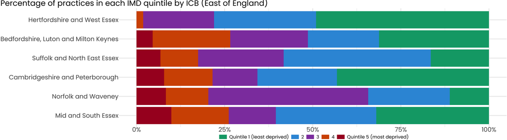

Each practice in England is assigned an Index of Multiple Deprivation (IMD) based on the population it serves, divided into deprivation quintiles.

For Bedfordshire, Luton and Milton Keynes, approximately **5%** of practices serve the most deprived quintile of patients in England.

## Inequality in Life Expectancy

[figure not shown]